# Silica Analysis

```r
df <- data.frame(silica = c(20, 10, 5, 10, 10, 5),
                 pm10 = c(310, 292, 209, 283, 161, 219))
```

# Linear Regression

```r
linear_fit <- lm(silica ~ pm10, data = df)
summary(linear_fit)
```

```
##
## Call:
## lm(formula = silica ~ pm10, data = df)
##
## Residuals:
##      1      2      3      4      5      6
##  6.346 -2.631 -2.918 -2.120  4.809 -3.486
##
## Coefficients:
##             Estimate Std. Error t value Pr(>|t|)
## (Intercept) -3.95228    9.44472  -0.418    0.697
## pm10         0.05679    0.03758   1.511    0.205
##
## Residual standard error: 4.886 on 4 degrees of freedom
## Multiple R-squared:  0.3635, Adjusted R-squared:  0.2043
## F-statistic: 2.284 on 1 and 4 DF,  p-value: 0.2052
```

### Checking assumptions

Assumptions we need to check: the residuals have constant variance and are normal and independent, The plots below allow us to check this. The plots of Residuals vs. Fitted Values and Residuals vs. Row indicate that there seems to be a pattern in the residuals, as opposed to being random which is what we want to see. The normal quantile plot also indicates that the assumption of normality of errors has been violated. Because of these violations the parameter estimates and any other insights we can derive from this model may be biased or incorrect. When this happens, we can try to apply transformations to the predictors.

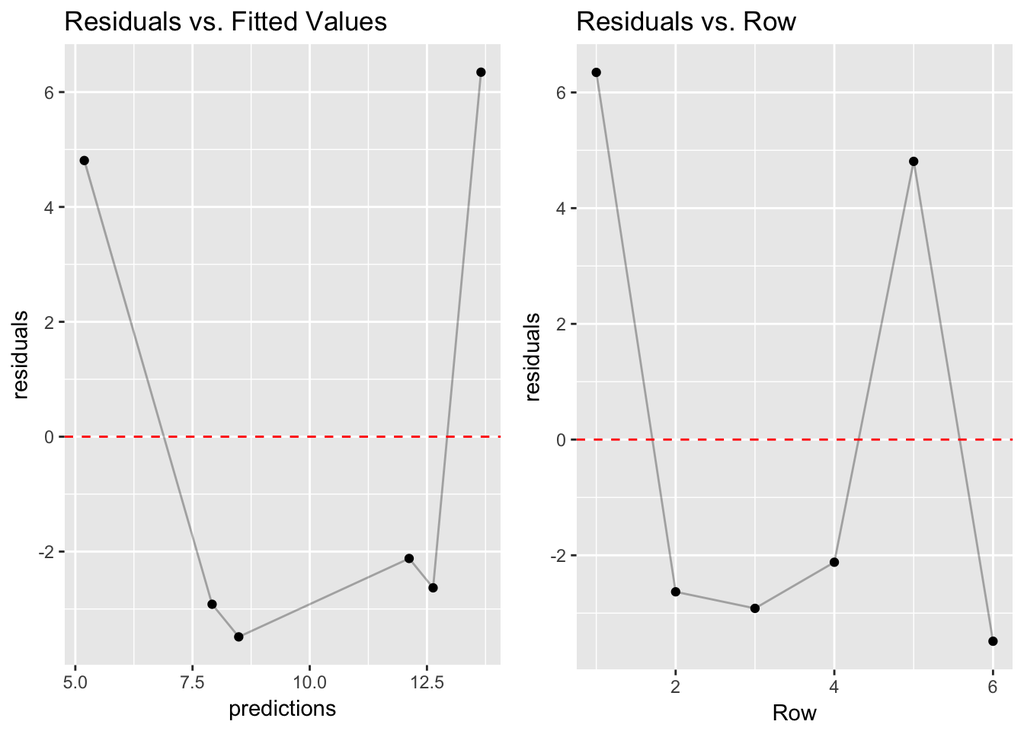

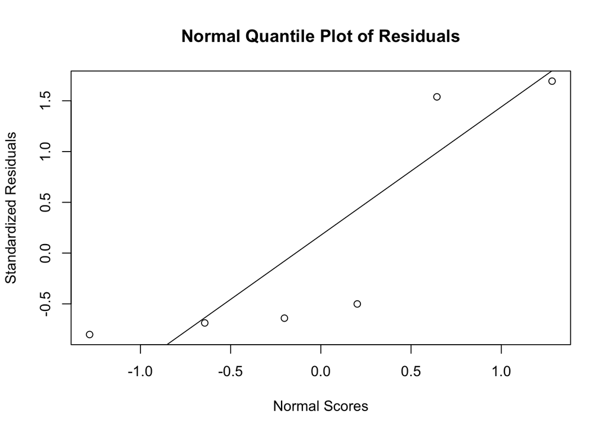

### Log transformation on PM10

```r
# log transformation applied to pm10
df$logpm10 <- log(df$pm10)
linear_fit2 <- lm(silica ~ logpm10, data = df)
```

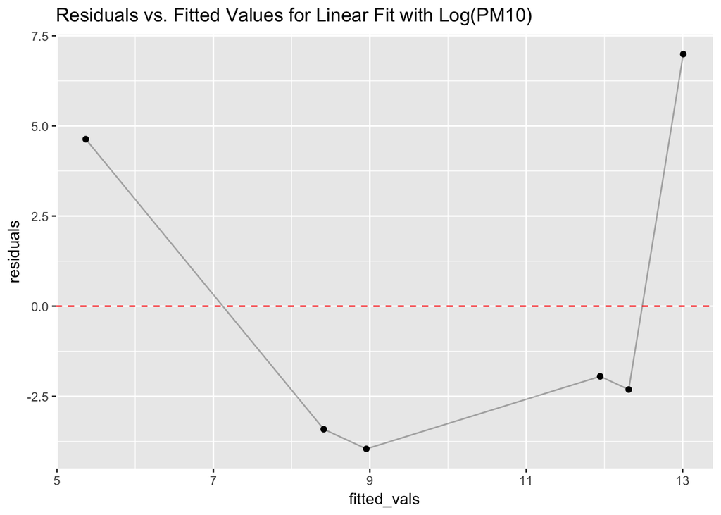

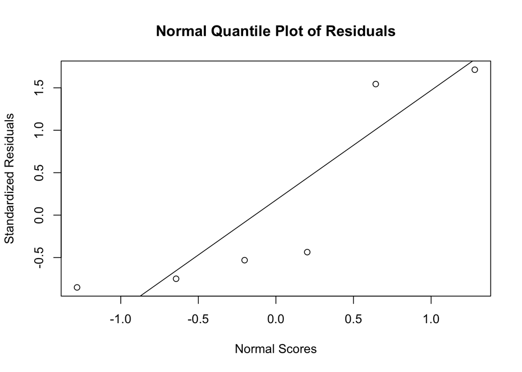

The above graphs assess the assumptions of the model with a log transformation applied to PM10. The graphs indicate that the transformation did not resolve the issue of error violations. I also tried several other transformations but the residuals plots looked similar to these. The next step I took in this case was to just explore the possibility of higher order terms in the model (though I know we don’t have a lot of data). For the analysis below, I switched the x and y variables so that this time, silica is predicting pm10.

### Exploring the Possibility of a Quadratic Fit

```r
quad_fit <- lm(pm10 ~ poly(silica, 2), data = df)
summary(quad_fit)
```

```
##
## Call:
## lm(formula = pm10 ~ poly(silica, 2), data = df)
##
## Residuals:
##          1          2          3          4          5          6
## -6.217e-15  4.667e+01 -5.000e+00  3.767e+01 -8.433e+01  5.000e+00
##
## Coefficients:
##                  Estimate Std. Error t value Pr(>|t|)
## (Intercept)      245.6667    24.4480  10.049   0.0021 **
## poly(silica, 2)1  78.3837    59.8851   1.309   0.2818
## poly(silica, 2)2   0.8165    59.8851   0.014   0.9900
## ---
## Signif. codes:  0 '***' 0.001 '**' 0.01 '*' 0.05 '.' 0.1 ' ' 1
##
## Residual standard error: 59.89 on 3 degrees of freedom
## Multiple R-squared:  0.3635, Adjusted R-squared:  -0.0608
## F-statistic: 0.8567 on 2 and 3 DF,  p-value: 0.5078
```

### Plotting the quadratic fit

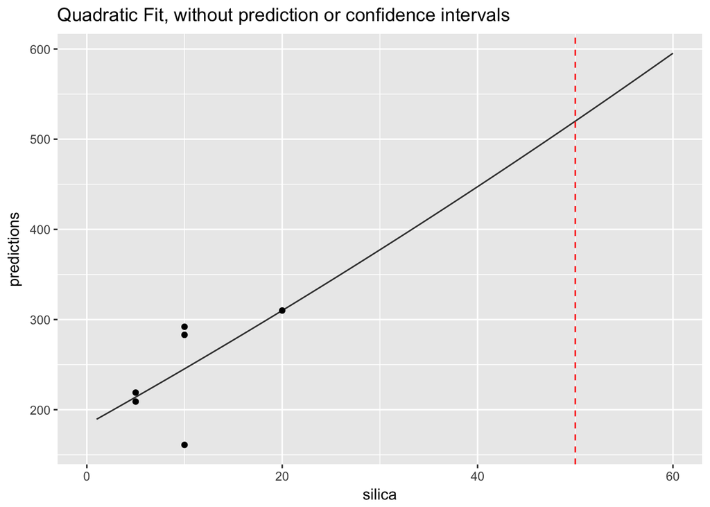

But plotting the prediction and confidence intervals indicates a huge amount of standard error around this fit.

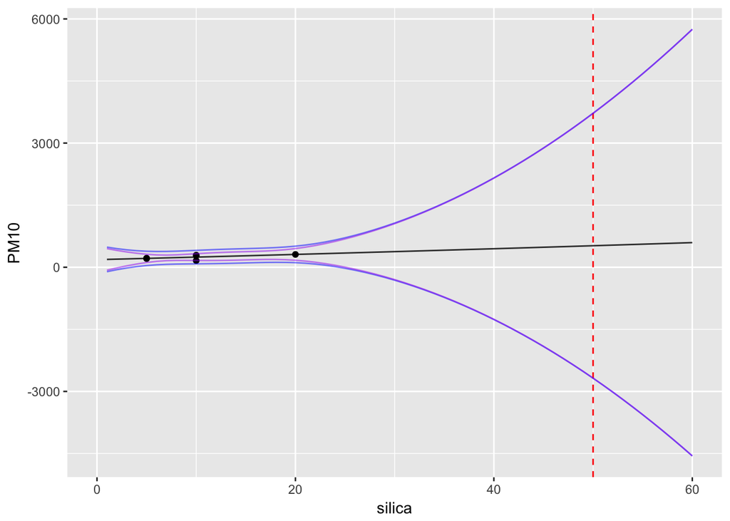

```r
pred <- data.frame(predict(quad_fit, newdata = data.frame(silica = 1:60),
                           se.fit = T, interval = "prediction", level = 0.90)$fit)
conf <- data.frame(predict(quad_fit, newdata = data.frame(silica = 1:60),
                           se.fit = T, interval = "confidence", level = 0.90)$fit)

# plot with prediction intervals
ggplot(quad_fitdf, aes(x = silica, y = predictions)) +
  geom_line(alpha = 0.8) +
  scale_x_continuous(limits = c(0, 60)) +
  scale_y_continuous("PM10") +
  geom_vline(xintercept = 50, col = "red", lty = 2) +
  geom_point(data = df, aes(x = silica, y = pm10)) +
  geom_line(data = pred, aes(x = 1:60, y = upr), alpha = 0.5, col = "blue") +
  geom_line(data = pred, aes(x = 1:60, y = lwr), alpha = 0.5, col = "blue") +
  geom_line(data = conf, aes(x = 1:60, y = upr), alpha = 0.5, col = "purple") +
  geom_line(data = conf, aes(x = 1:60, y = lwr), alpha = 0.5, col = "purple")
```

Plots below assess whether or not model assumptions are valid. Plot of Residuals vs. Fitted Values looks better than for linear regression. Residuals vs. Row Order also look better. The Normal Quantile plot also appears to look better, despite the one point at the bottom left.

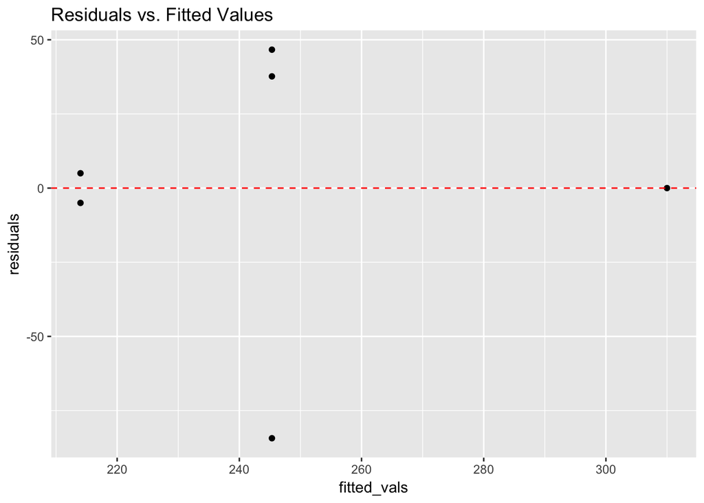

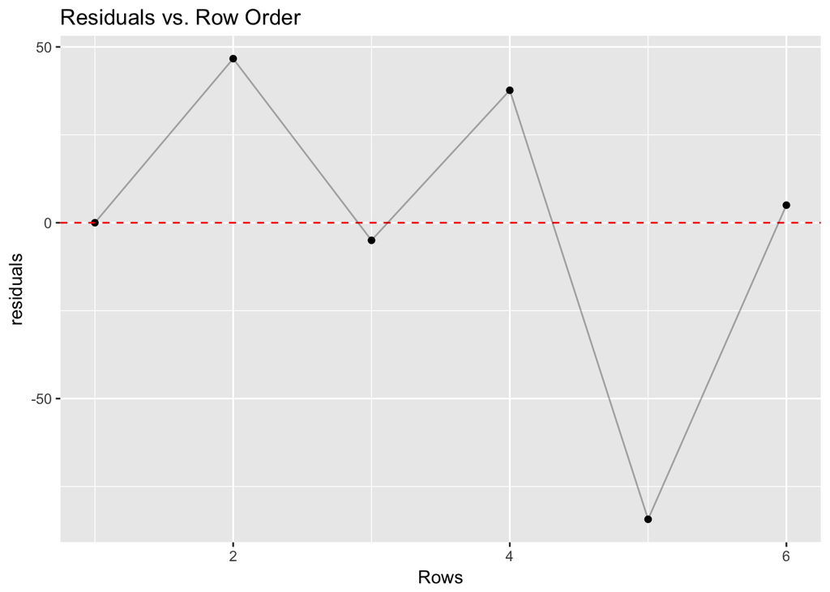

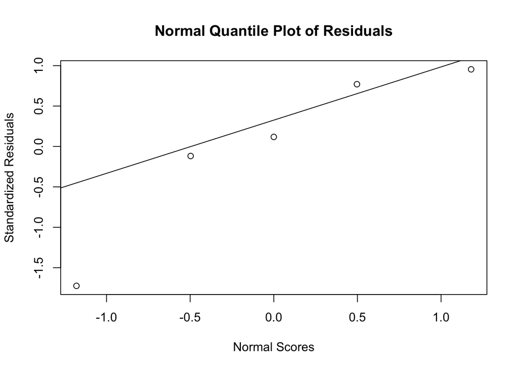

Below I have also checked the assumption of the regression on the log-transformed ratio of silica/PM10.

# Checking assumptions of log transformed ratio

The plot of Residuals vs. Fitted Values and Residuals vs. Rows look fine. The Normal Quantile plot also looks okay, though some points do seem to lie far from the line.

```r
logm <- lm(log(silica/pm10) ~ 1, data = df)
summary(logm)
```

```
##
## Call:
## lm(formula = log(silica/pm10) ~ 1, data = df)
##
## Residuals:
##        1        2        3        4        5        6
##  0.55070 -0.08263 -0.44136 -0.05133  0.51272 -0.48810
##
## Coefficients:
##             Estimate Std. Error t value Pr(>|t|)
## (Intercept)  -3.2915     0.1834  -17.95 9.85e-06 ***
## ---
## Signif. codes:  0 '***' 0.001 '**' 0.01 '*' 0.05 '.' 0.1 ' ' 1
##
## Residual standard error: 0.4491 on 5 degrees of freedom
```

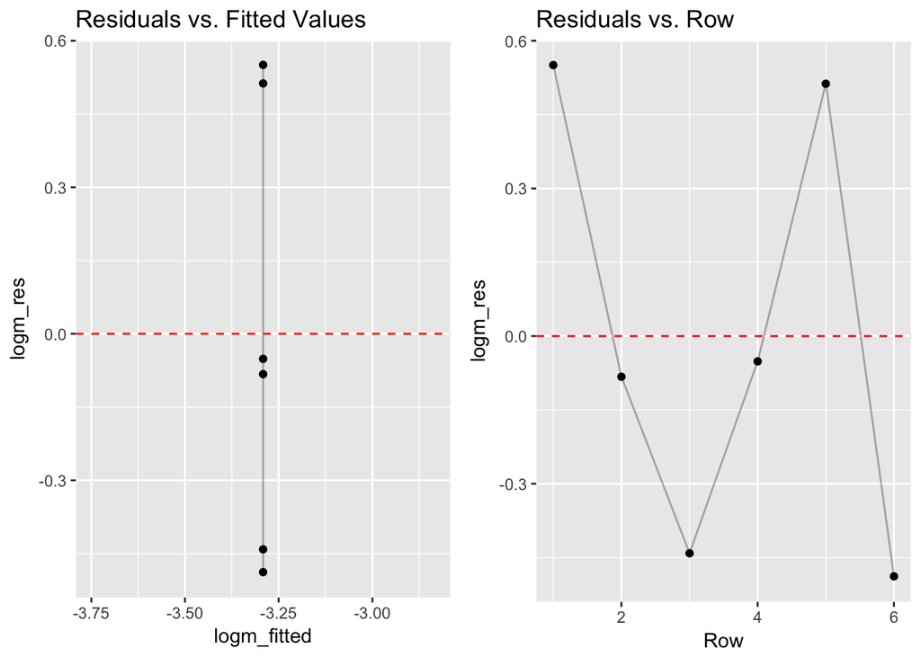

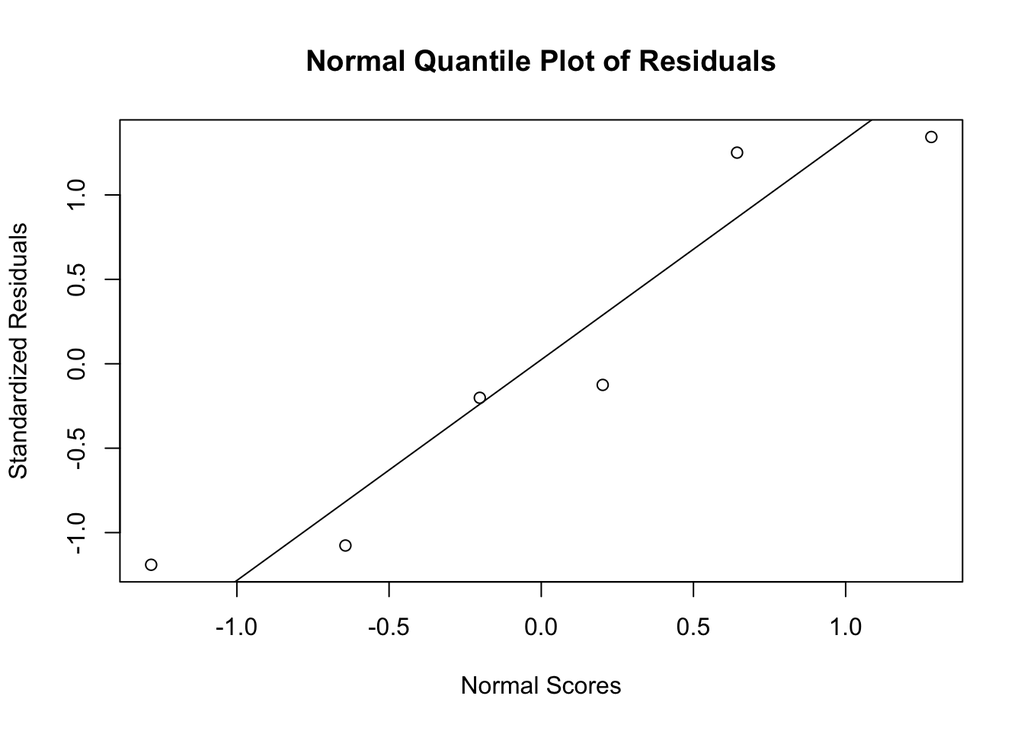

# Beta Regression (not sure if this is valid)

I also explored beta regression, which is good for when you want to model a continuous response that falls within the interval (0, 1). I’m unfamiliar with this method, but I think it might be great to look more into.

```r
library(betareg)

beta_fit <- betareg(I(silica/pm10) ~ 1, data = df)
summary(beta_fit)
```

```
##
## Call:
## betareg(formula = I(silica/pm10) ~ 1, data = df)
##
## Standardized weighted residuals 2:
##     Min      1Q  Median      3Q     Max
## -1.2557 -0.9081 -0.1811  0.9602  1.4278
##
## Coefficients (mean model with logit link):
##             Estimate Std. Error z value Pr(>|z|)
## (Intercept)  -3.1651     0.1724  -18.36   <2e-16 ***
##
## Phi coefficients (precision model with identity link):
##       Estimate Std. Error z value Pr(>|z|)
## (phi)   143.34      83.64   1.714   0.0866 .
## ---
## Signif. codes:  0 '***' 0.001 '**' 0.01 '*' 0.05 '.' 0.1 ' ' 1
##
## Type of estimator: ML (maximum likelihood)
## Log-likelihood: 16.46 on 2 Df
## Number of iterations: 2483 (BFGS) + 3 (Fisher scoring)
```